# The BATTLE Trial: A Case Study on Biomarker-Guided, Bayesian Adaptive Trial

- Show All Code
- Hide All Code
- View Source

How a 255-patient lung-cancer trial made mandatory biopsies, a hierarchical probit model, and outcome-adaptive randomization work in practice — and what it still teaches us about designing modern biomarker-directed trials

Published

September 10, 2026

# 1 Introduction

**BATTLE-1** offers a rare practical example of adaptive trial design. It was the first completed prospective, biopsy-mandated, biomarker-based, adaptively randomized trial in previously treated non-small-cell lung cancer (Kim et al. 2011; Liu and Lee 2015). At MD Anderson Cancer Center, 255 heavily pretreated patients were assigned to four oral targeted therapies using a Bayesian model updated with fresh biopsy biomarkers and 8-week outcomes. (Kim et al. 2011; Zhou et al. 2008).

BATTLE is a valuable teaching case for three reasons. First, **its design is thoroughly documented**, including the statistical model, adaptive-randomization algorithm, futility rules, and operating-characteristic targets (Zhou et al. 2008; Liu and Lee 2015; Lee, Gu, and Liu 2010). Second, **its operational lessons are as important as its statistics**: a multidisciplinary team developed a pipeline to biopsy patients, classify eleven biomarkers, and assign treatment within about two weeks (Kim et al. 2011; Tam et al. 2013; Liu and Lee 2015). Third, **its limitations are candidly reported**, including issues with biomarker grouping, burn-in duration, fragmented eligibility, and population drift (Liu and Lee 2015; Kim et al. 2011).

# 2 Clinical and scientific context (circa 2005)

## 2.1 The therapeutic plateau BATTLE attacked

By 2005, treatment options for metastatic NSCLC after first-line chemotherapy offered only modest survival gains (Herbst, Heymach, and Lippman 2008). At the same time, dramatic responses to the EGFR inhibitor gefitinib were observed in selected subgroups, and activating *EGFR* mutations were identified as the underlying predictor of sensitivity (Lynch, Bell, and Sordella 2004). The BR.21 trial subsequently showed a modest survival benefit with erlotinib in unselected patients and linked benefit to *EGFR* mutation status and gene copy number (M.-S. Tsao, Sakurada, and Cutz 2005).

Although the FDA approved erlotinib for previously treated NSCLC in November 2004 without molecular selection (Cohen, Johnson, and Pazdur 2005), an *EGFR* companion diagnostic was not approved until May 2013 (2013). Thus, when BATTLE was conceived, targeted therapies and predictive biomarkers were available, but prospective biomarker-guided treatment assignment had not yet been implemented in NSCLC (Kim et al. 2011; Liu and Lee 2015).

## 2.2 Why a new trial architecture was needed

The trialists at MD Anderson — Edward S. Kim, Roy S. Herbst, Waun Ki Hong, Ignacio Wistuba, and the biostatistics team led by J. Jack Lee — faced a combinatorial problem that classical phase II designs handle poorly (Kim et al. 2011; Liu and Lee 2015):

- **Many agents, many markers.** Four targeted agents (erlotinib, vandetanib, erlotinib + bexarotene, sorafenib) each plausibly worked only in marker-defined subgroups. The conventional alternative — 20 separate single-arm studies (4 agents × 5 marker classes) — would be slow, wasteful, and statistically fragile.
- **Unknowable markers in advance.** Which biomarker truly predicted benefit was unknown *before* the trial; a design that locked in subgroup definitions at protocol time risked answering the wrong question.
- **Stale tissue.** Biomarkers were usually assessed on archived diagnostic tissue, which may not reflect the biology of a tumor that had relapsed after multiple therapies (Liu and Lee 2015).

The BATTLE answer was architectural: one umbrella protocol, four parallel phase II sub-studies, a mandatory fresh biopsy for every patient, prespecified biomarker classes, and a Bayesian engine that reallocated future patients toward treatments performing well *in their marker class* as outcomes accumulated (Kim et al. 2011; Zhou et al. 2008).

## 2.3 Why the 8-week disease-control endpoint

Everything in an adaptive design lives or dies with how fast the outcome arrives. BATTLE chose **disease control at 8 weeks (DCR@8w)** — complete response, partial response, or stable disease by RECIST at week 8 — as the primary endpoint (Kim et al. 2011). The choice had empirical support: a Southwest Oncology Group analysis published while BATTLE was in development showed that disease control at 8 weeks predicted clinical benefit (survival) in advanced NSCLC (Lara, Redman, and Kelly 2008). It also had pragmatic virtues that a biostatistician should appreciate: it is quickly and objectively assessable, it suits the cytostatic profile of targeted agents (where tumor shrinkage is rare but stabilization is meaningful), and it turns around fast enough to inform randomization of the *next* patient (Kim et al. 2011; Zhou et al. 2008). The design paper was explicit that this short-turnaround property is what makes outcome-adaptive randomization viable at all (Zhou et al. 2008).

# 3 The BATTLE program at a glance

**Fact box — what is documented about BATTLE-1**

BATTLE-1 was a randomized phase II, single-center (MD Anderson Cancer Center), open-label umbrella trial with four parallel phase II sub-studies, activated on **November 30, 2006** and completed accrual on **October 28, 2009**. It enrolled **341** patients, of whom **255** were randomized (equal randomization for the first **97**, outcome-adaptive randomization for the remaining **158**). The primary endpoint was **8-week disease control (DCR@8w)**. Approval came from the MD Anderson IRB and the U.S. Department of Defense; an independent Data and Safety Monitoring Board (chaired by Donald A. Berry) monitored the trial. Funding came in part from DoD grant W81XWH-6-1-0303 and NCI Cancer Center Support Grant CA016672, with support also acknowledged from Merck Research Laboratories and Bayer HealthCare (Kim et al. 2011; Liu and Lee 2015). Sub-study registrations on ClinicalTrials.gov: umbrella protocol NCT00409968, erlotinib NCT00410059, vandetanib (ZD6474) NCT00410189, erlotinib + bexarotene NCT00411632, sorafenib NCT00411671 (all activated November 2006).

Table 1 collects the headline facts and Figure 1 places them in time; Table 2 details what each arm tested and where each drug stood regulatorily when the trial ran.

Table 1: Documented facts about BATTLE-1, compiled from the primary publication (Kim et al. 2011), the design paper (Zhou et al. 2008), and the trial biostatisticians’ overview (Liu and Lee 2015).

| Item | Documented value |
| --- | --- |
| Disease / setting | Advanced NSCLC, refractory to prior chemotherapy; median 2 prior regimens (range 1–6); prior erlotinib allowed (then excluded from erlotinib-containing arms) |
| Center / dates | MD Anderson Cancer Center; Nov 30, 2006 – Oct 28, 2009 |
| Enrolled → randomized | 341 enrolled; 255 randomized (17 patients randomized twice, 1 three times); 86 never randomized |
| Randomization scheme | Equal for first 97; Bayesian outcome-adaptive (marker-group-stratified) for the next 158 |
| Arms (oral agents) | Erlotinib 150 mg qd; vandetanib 300 mg qd; erlotinib 150 mg qd + bexarotene 400 mg/m² qd; sorafenib 400 mg bid |
| Biomarker program | Mandatory fresh core-needle biopsy; 11 prespecified biomarkers; 5 ranked marker groups; results ≤ 2 weeks |
| Primary endpoint | 8-week disease control rate (RECIST: CR/PR/SD at week 8) |
| Decision thresholds | Success: Pr(DCR > 30% \| data) ≥ 0.80; futility suspension: Pr(DCR > 50% \| data) ≤ 0.10 (reversible) |
| Design targets | ~250 randomized → 200 with complete marker profiles; ~80% power at a 20% type I error rate |
| Headline results | Overall DCR@8w 46% (112/244); median PFS 1.9 mo; median OS 8.8 mo; 1-year survival 35% |

Table 2: The four BATTLE-1 arms. Doses and suppliers are documented in the primary publication’s methods (Kim et al. 2011); approval statements are from FDA approval summaries and company announcements cited in the rightmost column.

| Arm | Agent(s) | Target pathway (as framed in 2005) | Company | U.S. regulatory status when BATTLE-1 ran |
| --- | --- | --- | --- | --- |
| 1 | Erlotinib | EGFR | OSI/Genentech | Approved (Nov 2004) for previously treated NSCLC (Cohen, Johnson, and Pazdur 2005) |
| 2 | Vandetanib | VEGFR2 + EGFR (dual) | AstraZeneca | Investigational in NSCLC; not approved until April 2011 (medullary thyroid cancer) (2011) |
| 3 | Erlotinib + bexarotene | EGFR + RXR/cyclin D1 | OSI/Genentech; Eisai | Erlotinib approved; bexarotene approved (1999) for cutaneous T-cell lymphoma; combination investigational (Kim et al. 2011) |
| 4 | Sorafenib | RAF/MEK/ERK and VEGFR (multikinase) | Bayer/Onyx | Approved (Dec 2005) for advanced renal-cell carcinoma; NSCLC use investigational (Kane, Farrell, and Sabharwal 2006) |

**Show the R code**

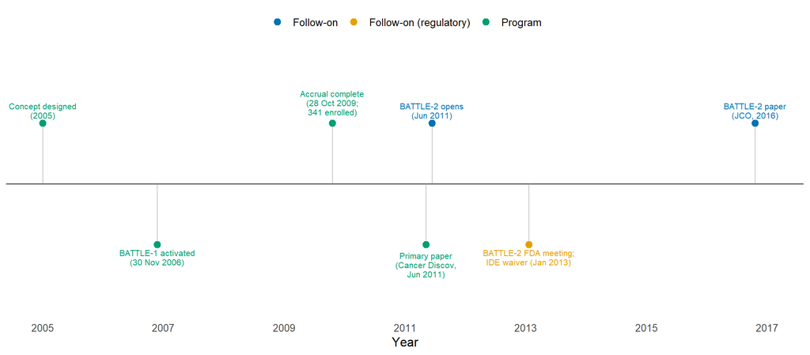

Figure 1: The BATTLE program timeline (documented events). Concept discussions began in 2005; BATTLE-1 was activated in November 2006 and completed accrual in October 2009; the primary publication appeared in June 2011; BATTLE-2 opened in June 2011, met the FDA in January 2013 (investigational device exemption waiver), and published in 2016. Constructed from Kim et al. (2011), Liu and Lee (2015), and Papadimitrakopoulou et al. (2016).

```r
events <- data.frame(
  year = c(2005.0, 2006.9, 2009.8, 2011.35, 2011.45, 2013.05, 2016.8),
  label = c("Concept designed\n(2005)",
            "BATTLE-1 activated\n(30 Nov 2006)",
            "Accrual complete\n(28 Oct 2009;\n341 enrolled)",
            "Primary paper\n(Cancer Discov,\nJun 2011)",
            "BATTLE-2 opens\n(Jun 2011)",
            "BATTLE-2 FDA meeting;\nIDE waiver (Jan 2013)",
            "BATTLE-2 paper\n(JCO, 2016)"),
  grp = c("Program", "Program", "Program", "Program",
          "Follow-on", "Follow-on (regulatory)", "Follow-on")
)
timeline_plot(events, xbreaks = seq(2005, 2017, 2))
```

Two registry facts complete the picture. First, patients who progressed could **re-enter the trial with a new biopsy and be re-randomized** — hence the 17 second and 1 third randomizations documented in the CONSORT diagram (Kim et al. 2011). Second, a front-line companion program, **BATTLE-FL** (NCT01263782), was later registered and completed with 64 participants, but this article focuses on BATTLE-1 and BATTLE-2, which carry the published methods lessons (Liu and Lee 2015).

**Why the umbrella-plus-sub-studies structure mattered**

Structurally, BATTLE-1 was “one protocol, four trials”: a single consent, a single screening biopsy, and a single randomization engine serving four parallel phase II sub-studies (Liu and Lee 2015). For a biostatistician the important consequence is **shared learning**: every patient’s outcome updated one common model, so information flowed across sub-studies through the hierarchical prior — something four separately conducted single-arm trials cannot do. The trialists explicitly credited this “all patients under one roof” feature with improving patient comparability and efficiency relative to sequential single-arm studies (Liu and Lee 2015).

# 4 Inside the design: objectives, biomarker engine, and the Bayesian machinery

## 4.1 What the trial promised to deliver

BATTLE aimed both to evaluate targeted therapies and establish a platform for estimating treatment-specific disease control rates (DCRs) within biomarker groups. Under one protocol, posterior probabilities governed three decisions (Zhou et al. 2008; Liu and Lee 2015):

1. **Success:** Declare an arm × marker-group cell successful if  
   $\Pr(\gamma_{jk} > 0.30 \mid \text{data}) \ge 0.80$ (Equation 8), relative to the historical 30% DCR (Kim et al. 2011; Lara, Redman, and Kelly 2008).
2. **Futility:** After adaptive randomization began, suspend a cell if  
   $\Pr(\gamma_{jk} > 0.50 \mid \text{data}) \le 0.10$ (Equation 7). Suspension was reversible (Zhou et al. 2008; Liu and Lee 2015).
3. **Adaptive randomization:** Assign patients among eligible, active treatments in proportion to the posterior mean DCR for their marker group (Equation 5) (Zhou et al. 2008).

Simulation calibrated these thresholds to limit the success rate to 20% under a 30% true DCR, while achieving at least 80% power at a 60% DCR and up to 95% at an 80% DCR (Zhou et al. 2008; Liu and Lee 2015). The deliberately liberal 20% type I error reflected the platform’s exploratory purpose: prioritizing potentially effective treatments for confirmation rather than prematurely discarding them (Kim et al. 2011; Zhou et al. 2008).

## 4.2 The two-stage architecture

**Show the R code**

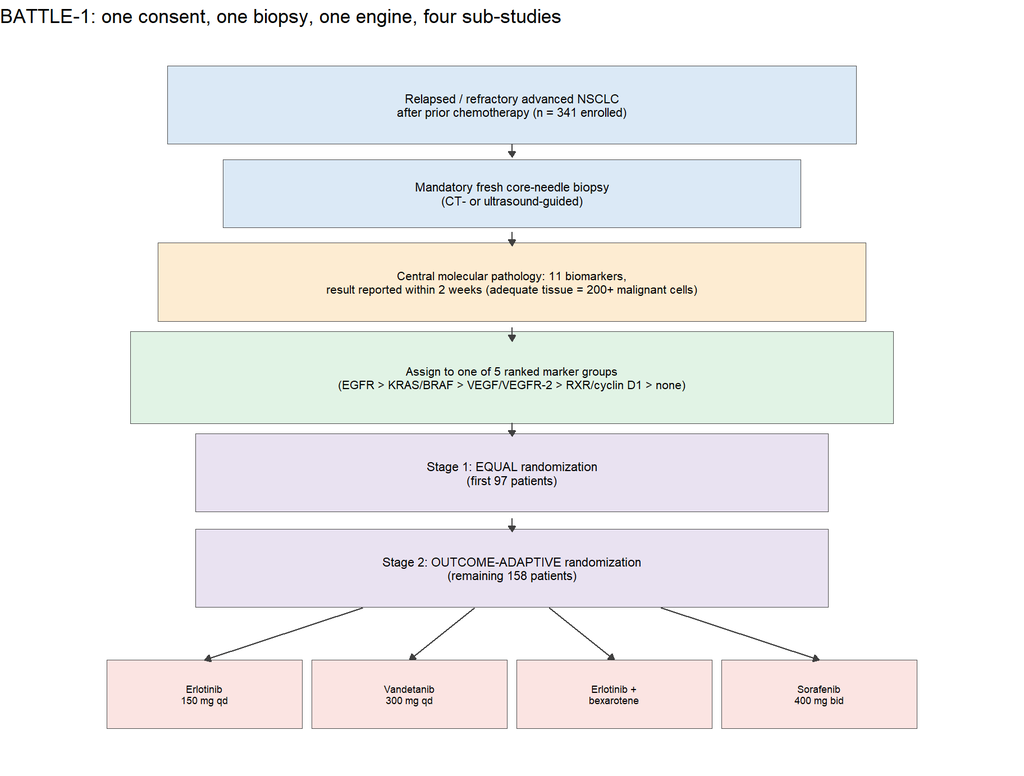

Figure 2: BATTLE-1 architecture (documented; drawn as a didactic diagram). Every enrolled patient underwent a mandatory fresh core-needle biopsy; eleven biomarkers were classified into five ranked marker groups; the first 97 randomized patients were allocated equally to the four arms (building the prior for the model), and the remaining 158 were randomized adaptively in proportion to posterior mean 8-week DCRs in their marker group, restricted to arms for which the patient was eligible. Diagram based on Kim et al. (2011), Zhou et al. (2008), and Liu and Lee (2015).

```r
boxes <- data.frame(
  x = c(5, 5, 5, 5, 5, 5, 1.7, 3.9, 6.1, 8.3),
  y = c(9.35, 8.05, 6.75, 5.35, 3.95, 2.55, 0.7, 0.7, 0.7, 0.7),
  w = c(7.4, 6.2, 7.6, 8.2, 6.8, 6.8, 2.1, 2.1, 2.1, 2.1),
  h = c(1.15, 1.0, 1.15, 1.35, 1.15, 1.15, 1.0, 1.0, 1.0, 1.0),
  fill = c("#D9E8F5", "#D9E8F5", "#FDEBD0", "#DFF2E4", "#E8E0F0", "#E8E0F0",
           "#FBE3E0", "#FBE3E0", "#FBE3E0", "#FBE3E0"),
  size = c(2.85, 2.85, 2.75, 2.75, 2.85, 2.85, 2.35, 2.35, 2.35, 2.35),
  label = c(
    "Relapsed / refractory advanced NSCLC\nafter prior chemotherapy (n = 341 enrolled)",
    "Mandatory fresh core-needle biopsy\n(CT- or ultrasound-guided)",
    "Central molecular pathology: 11 biomarkers,\nresult reported within 2 weeks (adequate tissue = 200+ malignant cells)",
    "Assign to one of 5 ranked marker groups\n(EGFR > KRAS/BRAF > VEGF/VEGFR-2 > RXR/cyclin D1 > none)",
    "Stage 1: EQUAL randomization\n(first 97 patients)",
    "Stage 2: OUTCOME-ADAPTIVE randomization\n(remaining 158 patients)",
    "Erlotinib\n150 mg qd",
    "Vandetanib\n300 mg qd",
    "Erlotinib +\nbexarotene",
    "Sorafenib\n400 mg bid"))
arrows <- data.frame(
  x = c(5, 5, 5, 5, 5), xend = c(5, 5, 5, 5, 5),
  y = c(8.78, 7.48, 6.08, 4.68, 3.28),
  yend = c(8.58, 7.28, 5.88, 4.48, 3.08))
arrows2 <- data.frame(
  x = c(3.4, 4.6, 5.4, 6.6), xend = c(1.7, 3.9, 6.1, 8.3),
  y = c(1.97, 1.97, 1.97, 1.97), yend = c(1.2, 1.2, 1.2, 1.2))
flow_diagram(boxes, rbind(arrows, arrows2)) +
  labs(title = "BATTLE-1: one consent, one biopsy, one engine, four sub-studies")
```

## 4.3 From 11 biomarkers to 5 marker groups

The biomarker panel was fixed in 2005 and prespecified before activation (Kim et al. 2011). Tumors were tested for **mutations** of *EGFR*, *KRAS*, and *BRAF*; **copy number** (FISH) of *EGFR* and the cyclin D1 gene (*CCND1*); and **protein expression** (IHC) of VEGF, VEGFR-2, RXRα, RXRβ, RXRγ, and cyclin D1 — eleven markers in total (Kim et al. 2011). Because dichotomizing eleven markers yields $2^{11} = 2{,}048$ possible profiles, the team collapsed them into **five ranked marker groups**, assigning each patient to the highest-ranked positive group (ranked by the strength of available 2005-era evidence), with a fifth group for patients negative for everything or with missing/incomplete data (Liu and Lee 2015; Kim et al. 2011):

Table 3: The five ranked marker groups. Grouping and ranking are documented in (Kim et al. 2011) (methods) and (Liu and Lee 2015) (Table 1 description); the sequential “highest-ranked positive group wins” rule is explicit in both.

| Rank | Marker group | Constituent biomarkers (any one positive) |
| --- | --- | --- |
| 1 | EGFR | *EGFR* mutation; *EGFR* amplification / high polysomy; increased *EGFR* copy number |
| 2 | KRAS/BRAF | *KRAS* mutation; *BRAF* mutation |
| 3 | VEGF/VEGFR-2 | VEGF overexpression; VEGFR-2 overexpression |
| 4 | RXR/cyclin D1 | RXRα, RXRβ, or RXRγ overexpression; cyclin D1 overexpression; *CCND1* amplification |
| 5 | None / unknown | No study biomarker positive, or biomarker data missing or incomplete |

Keep Table 3 in mind — the *grouping itself* became the trial’s most-cited self-criticism (Sections 7 and 8): strong single-marker effects (e.g., *EGFR* mutation for erlotinib) were diluted when bundled with weaker markers in the same class (Kim et al. 2011; Liu and Lee 2015).

## 4.4 The Bayesian hierarchical probit model

BATTLE’s outcome model is a **hierarchical probit model** — elegant, easy to Gibbs-sample, and pedagogically ideal because every piece has a trial-level meaning (Zhou et al. 2008). For patient $i$ in arm $j \in \{1,2,3,4\}$ and marker group $k \in \{1,\dots,5\}$, define $y_{ijk} \in \{0,1\}$ as the 8-week disease-control indicator. Introduce a latent variable $z_{ijk}$:

$$y_{ijk} = \mathbf{1}\{z_{ijk} > 0\}, \qquad z_{ijk} \sim \mathcal{N}(\mu_{jk},\, 1)
\tag{1}$$

Here $\mathbf{1}\{\cdot\}$ is the indicator function, $z_{ijk}$ is an unobserved “tolerance” that tips the patient into disease control when positive, and the variance is fixed at 1 for identifiability (the probit scale has no free scale parameter) (Zhou et al. 2008). The disease-control probability for the cell $(j,k)$ is then a smooth function of the cell mean $\mu_{jk}$:

$$\gamma_{jk} \;=\; \Pr(y_{ijk} = 1) \;=\; \Pr(z_{ijk} > 0) \;=\; \Phi(\mu_{jk}),
\tag{2}$$

The hierarchy enters through the prior on the cell means. Within an arm, the five marker-group means are exchangeable around an arm-level effect $\phi_j$; the arm effects are themselves exchangeable around zero (Zhou et al. 2008):

$$\mu_{jk} \sim \mathcal{N}(\phi_j,\, \sigma^2) \quad (k = 1,\dots,5), \qquad
\phi_j \sim \mathcal{N}(0,\, \tau^2) \quad (j = 1,\dots,4)
\tag{3}$$

with $\sigma^2 = \tau^2 = 10^6$ as the default *vague* configuration (Zhou et al. 2008). Read Equation 3 as two dials of **partial pooling**: small $\sigma^2$ makes the marker groups within an arm share information heavily (each group’s estimate is pulled toward the arm effect $\phi_j$); small $\tau^2$ makes the arms share information with each other. BATTLE ran these dials essentially open (vague priors), so borrowing happened only where the data themselves were concordant — the model “learns how much to borrow” from the observed pattern of subgroup results (Zhou et al. 2008; S. M. Berry et al. 2010).

Given the observed disease-control indicators, the posterior combines a probit likelihood with the normal priors:

$$p(\mu, \phi \mid \text{data}) \;\propto\;
\prod_{j=1}^{4} \prod_{k=1}^{5} \prod_{i=1}^{n_{jk}}
\Phi(\mu_{jk})^{y_{ijk}} \left[1 - \Phi(\mu_{jk})\right]^{1 - y_{ijk}}
\;\times\;
\prod_{j,k} \mathcal{N}(\mu_{jk} \mid \phi_j, \sigma^2)
\;\times\;
\prod_{j} \mathcal{N}(\phi_j \mid 0, \tau^2)
\tag{4}$$

**Interpretation — why a probit rather than a logit?**

The probit link is not a substantive claim about biology; it is a **computational convenience**. With normal priors on $\mu_{jk}$, the full conditionals are (truncated) normals, so Gibbs sampling is exact and fast — no Metropolis–Hastings tuning in the middle of a live trial. A logistic model with the same hierarchy (used later for BATTLE-2, (Lee, Gu, and Liu 2010)) would deliver nearly identical inferences; the choice reflects 2006-era Bayesian computation practice, an excellent example of letting the computing environment shape — not distort — the statistics.

Figure 3 makes the “borrowing strength” idea concrete with a small simulation.

**Show the R code**

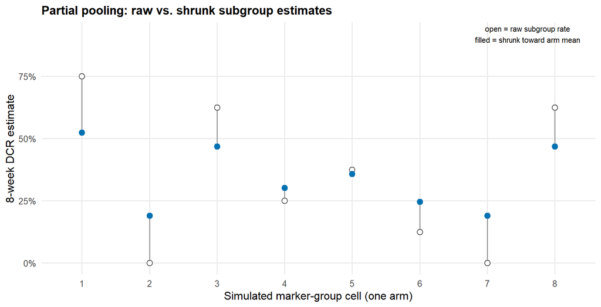

Figure 3: Illustrative simulation — partial pooling in one arm. Eight marker-group-like subgroups (n = 8 each) are generated from a probit-scale hierarchy similar in spirit to Equation 3 (subgroup means centered at a DCR of 40%, subgroup SD 0.35 on the probit scale). Open circles: raw subgroup DCRs. Filled circles: posterior-mean-style shrunk estimates $(x + \kappa\,\bar p)/(n + \kappa)$ with $\kappa = 10$, a Beta–Binomial stand-in for the trial’s probit-scale pooling. Subgroups whose raw rate is extreme are pulled toward the arm average — this is the ‘borrowing strength’ that stabilized all 20 cells of BATTLE-1 with small $n_{jk}$.

```r
set.seed(7)
k_grp <- 8; n_per <- 8; kappa <- 10
mu_sim   <- rnorm(k_grp, qnorm(0.40), 0.35)
p_true   <- pnorm(mu_sim)
x_sim    <- rbinom(k_grp, n_per, p_true)
p_raw    <- x_sim / n_per
p_bar    <- sum(x_sim) / (k_grp * n_per)
p_shrunk <- (x_sim + kappa * p_bar) / (n_per + kappa)
shr <- data.frame(group = factor(1:k_grp), p_raw, p_shrunk)
ggplot(shr, aes(x = group, xend = group)) +
  geom_segment(aes(y = p_raw, yend = p_shrunk), colour = "grey60",
               linewidth = 0.6, arrow = arrow(length = unit(0.12, "cm"))) +
  geom_point(aes(y = p_raw), shape = 21, size = 2.6, fill = "white", colour = "grey30") +
  geom_point(aes(y = p_shrunk), size = 2.6, colour = pal[1]) +
  scale_y_continuous(labels = percent) +
  labs(x = "Simulated marker-group cell (one arm)",
       y = "8-week DCR estimate",
       title = "Partial pooling: raw vs. shrunk subgroup estimates") +
  annotate("text", x = 7.6, y = 0.92, size = 2.9,
           label = "open = raw subgroup rate\nfilled = shrunk toward arm mean")
```

## 4.5 The adaptive-randomization engine

Once every one of the 20 cells (4 arms × 5 groups) contained at least one patient with a known outcome, randomization switched from equal to **outcome-adaptive**. For the next patient in marker group $k$, the probability of assignment to arm $j$ was proportional to the *posterior mean* disease-control rate of that cell, with two safeguards (Zhou et al. 2008):

$$w_{jk} \;=\; \frac{\hat\gamma_{jk}}{\sum_{\omega \in \Omega}\hat\gamma_{\omega k}},
\qquad
\hat\gamma_{jk} = \max\!\big\{\, \mathbb{E}[\gamma_{jk} \mid \text{data}],\; 0.10 \,\big\}
\tag{5}$$

In Equation 5, $\hat\gamma_{jk}$ is the posterior mean DCR for arm $j$ in group $k$ (floored at 0.10 so no non-suspended arm ever becomes essentially unreachable — the trial’s explicit minimum-allocation device (Zhou et al. 2008)), and $\Omega$ is the set of arms that are both **non-suspended for futility** and **eligible for that patient** (recall: only 14% of patients were eligible for all four arms (Liu and Lee 2015)). The published worked example (Zhou et al. 2008) makes the weights tangible: if the current posterior mean DCRs in a marker group were 0.6, 0.3, 0.2, and 0.1, the assignment probabilities become 0.50, 0.25, 0.17, and 0.08.

Two remarks for the practicing statistician. First, this is **covariate-adjusted adaptive randomization**: the weights are computed *within marker group*, so the adaptation respects the stratification — the trial learns “which arm works best *for tumors like this one*” rather than a single global winner. Second, BATTLE-1’s rule is the plainest member of the broader family of Bayesian adaptive-randomization rules popularized by Thall and Wathen, who add a **power smoothing** so that early, noisy estimates do not over-steer allocation (Thall and Wathen 2007):

$$w_j^{(m)} \;=\; \frac{\bar p_j^{\,q(m)}}{\sum_{\ell} \bar p_\ell^{\,q(m)}},
\qquad
q(m) \;=\; \frac{m/4 + 8}{m},
\tag{6}$$

where $m$ indexes trial progress, $\bar p_j$ is the current probability that arm $j$ is (or performs) best, and $q(m) > 1$ early (dampening) falls below 1 later (sharpening). BATTLE-1 used the unsmoothed proportional form of Equation 5; its successor BATTLE-2 instead **bounded** the randomization probabilities (0.2–0.8 in stage 1, 0.1–0.9 in stage 2) to prevent extreme allocations from either noise or premature certainty (Liu and Lee 2015). If you implement one of these designs today, the choice among {no smoothing, power smoothing, probability bounds} is exactly the kind of decision to justify by simulation. Figure 4 shows what the BATTLE-1-style engine does in silico when seeded with the trial’s own marginal response rates.

**Show the R code**

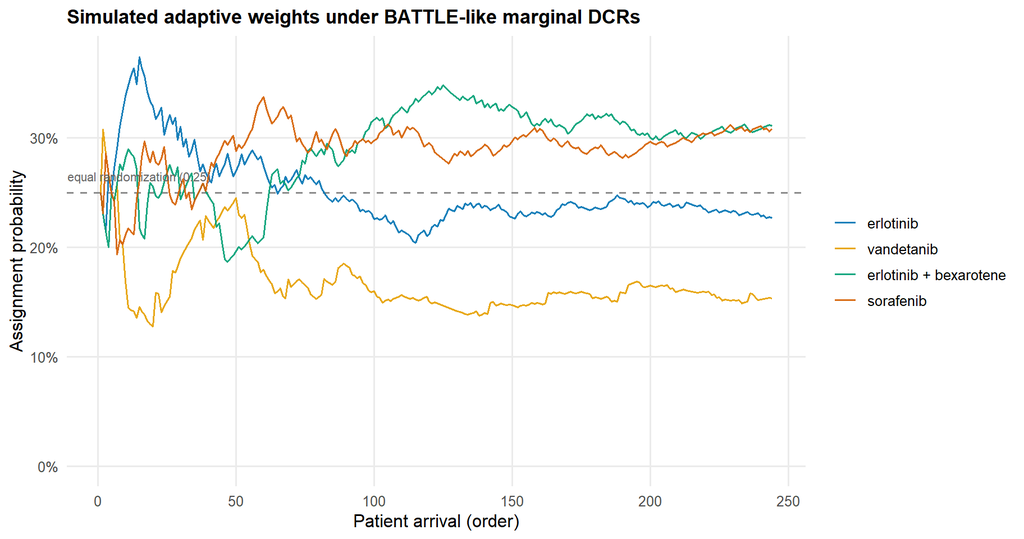

Figure 4: Illustrative simulation — how outcome-adaptive randomization behaves. A Beta–Bernoulli approximation of Equation 5 (not the trial’s probit model) allocates 244 sequential patients among four arms with true 8-week DCRs set to BATTLE’s observed marginal rates (erlotinib 34%, vandetanib 33%, erlotinib + bexarotene 50%, sorafenib 58%; Kim et al. (2011)). Each point is the assignment probability at that patient; the 10% floor of Equation 5 and normalization over arms are applied. Weights drift toward the better arms as evidence accumulates; note they start near 0.25 (equal) and remain noisy because only the assigned arm’s outcome updates. In the real trial, additionally, 8-week outcomes arrive with delay, so the engine ran on partially stale data.

```r
set.seed(41)
truth_ar <- c(E = 0.34, V = 0.33, EB = 0.50, S = 0.58)
n_pat <- 244
s_ar <- n_ar <- rep(0, 4)
w_hist <- matrix(NA_real_, n_pat, 4)
for (i in seq_len(n_pat)) {
  phat   <- (s_ar + 1) / (n_ar + 2)      # Beta(1,1) posterior mean
  w_arms <- pmax(phat, 0.10)             # 10% floor
  w_arms <- w_arms / sum(w_arms)
  w_hist[i, ] <- w_arms
  j <- sample(4, 1, prob = w_arms)
  n_ar[j] <- n_ar[j] + 1
  s_ar[j] <- s_ar[j] + rbinom(1, 1, truth_ar[j])
}
colnames(w_hist) <- names(truth_ar)
w_df <- as.data.frame(w_hist) |>
  mutate(patient = row_number()) |>
  pivot_longer(-patient, names_to = "arm", values_to = "probability")
w_df$arm <- factor(w_df$arm, levels = names(truth_ar),
                   labels = c("erlotinib", "vandetanib",
                              "erlotinib + bexarotene", "sorafenib"))
ggplot(w_df, aes(patient, probability, colour = arm)) +
  geom_hline(yintercept = 0.25, linetype = 2, colour = "grey55") +
  geom_line(linewidth = 0.7, alpha = 0.9) +
  scale_colour_manual(values = pal) +
  scale_y_continuous(labels = percent, limits = c(0, NA)) +
  labs(x = "Patient arrival (order)", y = "Assignment probability",
       title = "Simulated adaptive weights under BATTLE-like marginal DCRs") +
  annotate("text", x = 15, y = 0.265, size = 2.9, colour = "grey40",
           label = "equal randomization (0.25)")
```

## 4.6 Futility monitoring: suspension, not execution

After adaptive randomization began, each new outcome re-triggered a futility check for every cell. A cell was **suspended** — patients in marker group $k$ could no longer be randomized to arm $j$ — whenever

$$\Pr\{\gamma_{jk} > 0.50 \mid \text{data}\} \;\le\; 0.10,
\tag{7}$$

i.e., when the data made it unlikely (posterior probability ≤ 10%) that the cell’s true DCR exceeded the 50% target (Zhou et al. 2008; Liu and Lee 2015). Three features of this rule reward attention. **It is cell-specific**: the same arm could stay open for one marker group while suspended for another — the entire point of a biomarker-guided design. **It is reversible**: if later data (e.g., from other marker groups borrowed through the hierarchy) lifted the posterior back above the boundary, the cell reopened (Zhou et al. 2008). And **there is no early stopping for efficacy**: success was only declared at trial end, so adaptation and inference could never race each other (Zhou et al. 2008). The success rule itself, applied to every cell at the trial’s close, was

$$\Pr\{\gamma_{jk} > 0.30 \mid \text{data}\} \;\ge\; 0.80,
\tag{8}$$

i.e., a posterior probability of at least 0.80 that the cell’s true DCR exceeds the 30% historical benchmark (Zhou et al. 2008; Kim et al. 2011).

**Show the R code**

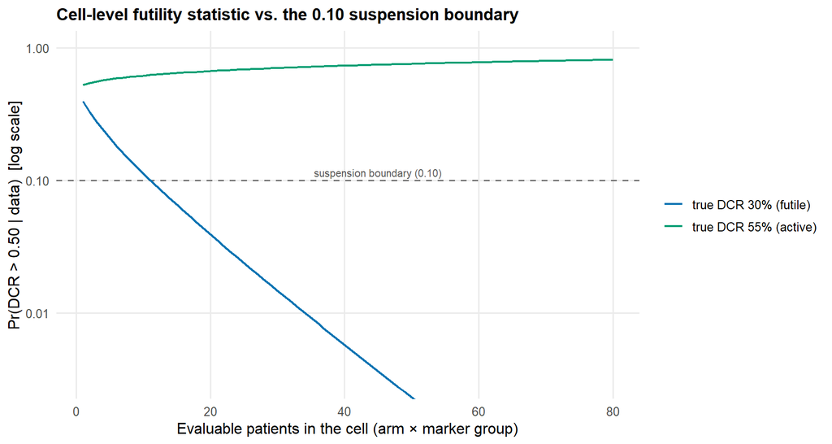

Figure 5: Illustrative trajectory of the futility statistic in Equation 7. For a cell whose observed DCR tracks a true rate of 30% (blue) the posterior probability Pr(DCR > 0.50 | data) decays quickly below the 0.10 suspension boundary; for a cell tracking 55% (green) it never approaches it. Computed analytically under a Beta(1,1) posterior with expected success counts $m p$ after $m$ evaluable patients (a deterministic stand-in for a single noisy path). In BATTLE-1 the same logic ran on actual outcomes for all 20 cells after every updated endpoint, with suspension reversible (Zhou et al. 2008).

```r
m_seq <- 1:80
fut_curve <- function(p_true) {
  sapply(m_seq, function(mm) 1 - pbeta(0.50, mm * p_true + 1, mm * (1 - p_true) + 1))
}
fut_df <- data.frame(
  m = rep(m_seq, 2),
  prob = c(fut_curve(0.30), fut_curve(0.55)),
  scenario = rep(c("true DCR 30% (futile)", "true DCR 55% (active)"), each = length(m_seq)))
ggplot(fut_df, aes(m, prob, colour = scenario)) +
  geom_hline(yintercept = 0.10, linetype = 2, colour = "grey45") +
  geom_line(linewidth = 0.85) +
  scale_colour_manual(values = c(pal[1], pal[3])) +
  scale_y_log10(labels = label_number()) +
  coord_cartesian(ylim = c(0.003, 1)) +
  labs(x = "Evaluable patients in the cell (arm × marker group)",
       y = "Pr(DCR > 0.50 | data)  [log scale]",
       title = "Cell-level futility statistic vs. the 0.10 suspension boundary") +
  annotate("text", x = 45, y = 0.115, size = 2.9, colour = "grey35",
           label = "suspension boundary (0.10)")
```

# 5 The biomarker engine: real-time tissue from relapsed lung cancer

## 5.1 The pipeline, step by step

The boldest requirement of BATTLE was not statistical. Every enrolled patient had to consent to a **fresh tumor biopsy** after relapse — in a population already heavily treated, with lesions that are often hard to reach (Kim et al. 2011; Liu and Lee 2015). Figure 6 reconstructs the documented pipeline.

**Show the R code**

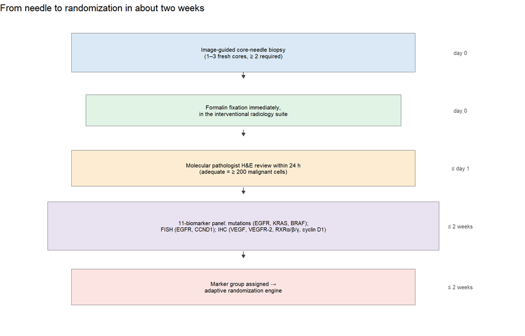

Figure 6: The real-time tissue pipeline (documented; diagram is didactic). An interventional radiologist obtained 1–3 fresh cores (~1 mm diameter, 1.2–1.8 cm long; minimum two cores required) under CT or ultrasound guidance; specimens were formalin-fixed immediately in the radiology suite; a molecular pathologist reviewed H&E sections within 24 hours (adequacy = at least 200 malignant cells); the 11-biomarker panel (mutations of EGFR/KRAS/BRAF; FISH copy number for EGFR and CCND1; IHC for VEGF, VEGFR-2, RXRα/β/γ, cyclin D1) was reported within two weeks; the marker group then fed the randomization engine. Sources: Kim et al. (2011) (methods), Liu and Lee (2015).

```r
bx <- data.frame(
  x = c(4.6, 4.6, 4.6, 4.6, 4.6),
  y = c(9.2, 7.35, 5.5, 3.65, 1.7),
  w = c(7.2, 6.6, 7.2, 8.2, 7.2),
  h = c(1.25, 1.0, 1.15, 1.55, 1.15),
  fill = c("#D9E8F5", "#DFF2E4", "#FDEBD0", "#E8E0F0", "#FBE3E0"),
  size = c(2.8, 2.75, 2.75, 2.6, 2.8),
  label = c(
    "Image-guided core-needle biopsy\n(1–3 fresh cores, ≥ 2 required)",
    "Formalin fixation immediately,\nin the interventional radiology suite",
    "Molecular pathologist H&E review within 24 h\n(adequate = ≥ 200 malignant cells)",
    "11-biomarker panel: mutations (EGFR, KRAS, BRAF);\nFISH (EGFR, CCND1); IHC (VEGF, VEGFR-2, RXRα/β/γ, cyclin D1)",
    "Marker group assigned →\nadaptive randomization engine"))
ba <- data.frame(x = c(4.6, 4.6, 4.6, 4.6), xend = c(4.6, 4.6, 4.6, 4.6),
                 y = c(8.58, 6.73, 4.88, 2.83), yend = c(8.38, 6.53, 4.68, 2.63))
flow_diagram(bx, ba, ylim = c(0.6, 10)) +
  annotate("text", x = 9.15, y = c(9.2, 7.35, 5.5, 3.65, 1.7), size = 2.6,
           colour = "grey35", hjust = 0.5,
           label = c("day 0", "day 0", "≤ day 1", "≤ 2 weeks", "≤ 2 weeks")) +
  labs(title = "From needle to randomization in about two weeks")
```